# Reproducible Research: Peer Assessment 1

## Loading and preprocessing the data

Setup Knitr

Reading and preprocessing the data

```r
data <- read.csv("activity.csv")
data$date <- as.POSIXct(data$date, format = "%Y-%m-%d")

summary(data)
```

```
##      steps             date               interval
##  Min.   :  0.00   Min.   :2012-10-01   Min.   :   0.0
##  1st Qu.:  0.00   1st Qu.:2012-10-16   1st Qu.: 588.8
##  Median :  0.00   Median :2012-10-31   Median :1177.5
##  Mean   : 37.38   Mean   :2012-10-31   Mean   :1177.5
##  3rd Qu.: 12.00   3rd Qu.:2012-11-15   3rd Qu.:1766.2
##  Max.   :806.00   Max.   :2012-11-30   Max.   :2355.0
##  NA's   :2304
```

## What is mean total number of steps taken per day?

Calculate the total number of steps taken per day

```r
total_steps <- aggregate.data.frame(data$steps, list(data$date), sum, na.rm=T)
names(total_steps) <- c("date", "steps")
```

Make a histogram of the total number of steps taken each day

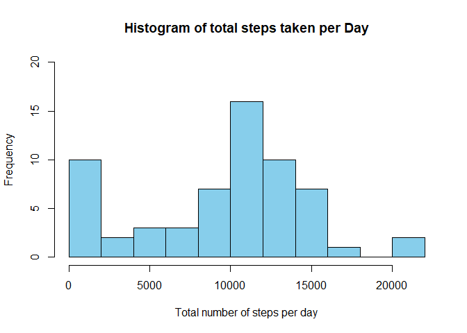

```r
hist(total_steps$steps, breaks = 10, col = "skyblue", main = "Histogram of total steps taken per Day",
      xlab = "Total number of steps per day", ylim = c(0,20))
```

Calculating the mean of the total number of steps taken per day

```r
total_steps_mean <- mean(total_steps$steps)
total_steps_mean
```

```
## [1] 9354.23
```

Calculating the median of the total number of steps taken per day

```r
total_steps_median <- median(total_steps$steps)
total_steps_median
```

```
## [1] 10395
```

## What is the average daily activity pattern?

Average steps per 5 minutes interval and making a time series plot

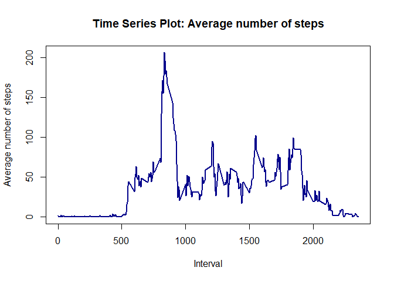

```r
average_daily_activity <- aggregate.data.frame(data$steps, by=list(data$interval),mean, na.rm=TRUE)
names(average_daily_activity) <- c("interval", "mean")
attach(average_daily_activity)
plot(interval, mean, type = "l", col="darkblue", lwd=2,
     main = "Time Series Plot: Average number of steps",
     ylab = "Average number of steps",
     xlab = "Interval")
```

```r
detach(average_daily_activity)
```

Which 5-minute interval, on average across all the days in the dataset, contains the maximum number of steps?

```r
average_daily_activity[which.max(average_daily_activity$mean), ]$interval
```

```
## [1] 835
```

## Imputing missing values

Total number of missing values in the dataset

```r
sum(is.na(data$steps))
```

```
## [1] 2304
```

Devise a strategy for filling in all of the missing values in the dataset. Creating a new dataset that is equal to the original dataset but with the missing data filled in.

```r
data_complete <- data
data_complete$steps[is.na(data_complete$steps)] <- round(mean(average_daily_activity$mean))
```

Making a histogram of the total number of steps taken each day and calculate and report the mean and median total number of steps taken per day.

[figure not shown]

```r
total_steps_new <- aggregate.data.frame(data_complete$steps, list(data_complete$date), sum, na.rm=T)
names(total_steps_new) <- c("date", "steps")

hist(total_steps_new$steps, breaks = 10, col = "pink",
     main = "Histogram of total steps taken per Day",
     sub = "NA's removed",
     xlab = "Total number of steps per day", ylim = c(0,30))
```

Calculating the mean of the new total number of steps taken per day

```r
total_steps_mean2 <- mean(total_steps_new$steps)
total_steps_mean2
```

```
## [1] 10751.74
```

Calculating the median of the new total number of steps taken per day

```r
total_steps_median2 <- median(total_steps_new$steps)
total_steps_median2
```

```
## [1] 10656
```

## Are there differences in activity patterns between weekdays and weekends?

Creating a new factor variable in the dataset with two levels – “weekday” and “weekend” indicating whether a given date is a weekday or weekend day.

```r
data_complete$NewDate <- as.Date(data_complete$date, format = "%Y-%m-%d")
data_complete$Weekday <- weekdays(data_complete$NewDate)
data_complete$dateType <- ifelse(data_complete$Weekday=="sábado" | data_complete$Weekday=="domingo", "weekend","weekday")
```

Making a panel plot containing a time series plot of the 5-minute interval (x-axis) and the average number of steps taken, averaged across all weekday days or weekend days (y-axis).

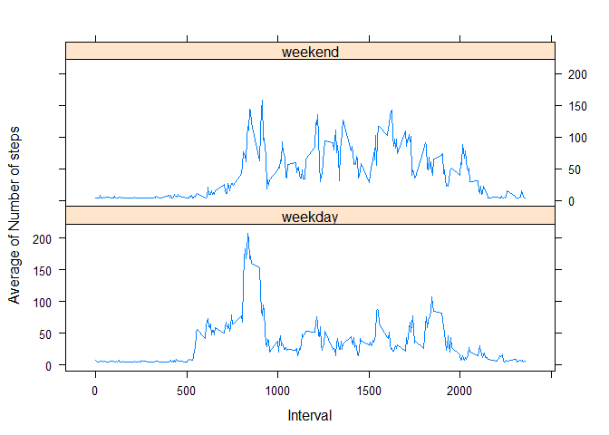

```r
average_daily_activity_new <- aggregate(steps~interval+dateType,data=data_complete,mean,na.rm=TRUE)
library(lattice)
xyplot(steps ~ interval | factor(dateType),
       layout = c(1, 2),
       xlab="Interval",
       ylab="Average of Number of steps",
       type="l",
       lty=1,
       data=average_daily_activity_new)
```